# SCOP_2021_0135 Hypothalamus Frontal Cortex Combined analysis

```r
library("cbmr")
```

```r
library("limma")
library("edgeR")
library("ggplot2")
library("data.table")
library("stringr")
library("clipr")
library("org.Mm.eg.db")
library("clusterProfiler")
library("pheatmap")
library("RColorBrewer")

load(here::here("data/hyp_pfc.rda"))
counts <- hyp_pfc$counts
metadata <- hyp_pfc$metadata
```

## Introduction

In the metadata the short term effect is written as “3 hours post-injection” and “4 weeks post-injection”, for ease of coding the time points are renamed to 3hours and 4weeks.

```r
metadata[, `Condition 2`:=fifelse(`Condition 2` == "4 weeks post-injection",
                                  "4weeks", "3hours")]
```

Two tissues are investigated, Hypothalamus and Frontal Cortex (PFC).

## Initial assesment of data quality

From the multiQC report generated as part of the alignment and feature counting, we know that the samples have a very consistent alignment and assignment rate, but that one sample from each tissue (sample A2 and B6) have almost no reads. In general the number of reads in each sample is fine. Few samples have a somewhat higher proportion of multi-mapping reads than the remaining samples. The two sample with very few reads will be excluded as 200.000 reads is not enough to test for differential expression.

```r
y <- prepare_rna_dgelist(counts, metadata, sample_col = "Sample ID (Library ID)")
rownames(y) <- str_remove(y$genes$Geneid, "\\.[[:digit:]]+$")

# Density and MD plots are saved to an external file. The filtered
# ones are the more relevant ones.

y <- y[, !(y$samples$Sample.ID..Library.ID. %in% c("0135A_2", "0135B_6"))]

y$samples$group <- factor(paste0(y$samples$Condition.1, "_",
                                 y$samples$Condition.2
))

design <- model.matrix(~ 0 + group:tissue, data = y$samples)

idx_expressed <- filterByExpr(y, design = design)
y <- y[idx_expressed, ]

p2 <- plot_density(y)
pdf(here::here("doc/all_filtered_plots.pdf"))
p2
plot_all_md(y)
dev.off()
```

The samples follow the same distribution of reads.

### Visalization of all samples

Next we visualize the distribution of the individual samples as both a number of multidimensional scaling (MDS) plots:

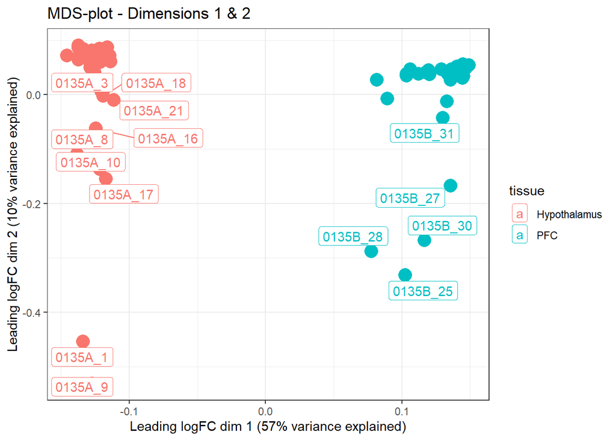

```r
colour_scale <- scale_color_manual(name = NULL,
                                   values = c("Saline_3hours" = "#a6cee3",
                                              "Psilocybin_3hours" = "#1f78b4",
                                              "Saline_4weeks" = "#b2df8a",
                                              "Psilocybin_4weeks" = "#33a02c"),
                                   labels = c("Saline_3hours" = "Saline, 3 hours",
                                              "Psilocybin_3hours" = "Psilocybin, 3 hours",
                                              "Saline_4weeks" = "Saline, 4 weeks",
                                              "Psilocybin_4weeks" = "Psilocybin, 4 weeks")
)

p <- ggplot_mds(y, dim_plot = c(1, 2),
                colour_by = "tissue"
)
p
```

It is obvious that the major difference between samples is due to tissue differences, this is not surprising and we instead visualize the tissues separately.

### Visalization and investigation of potential outliers in Hypothalamus

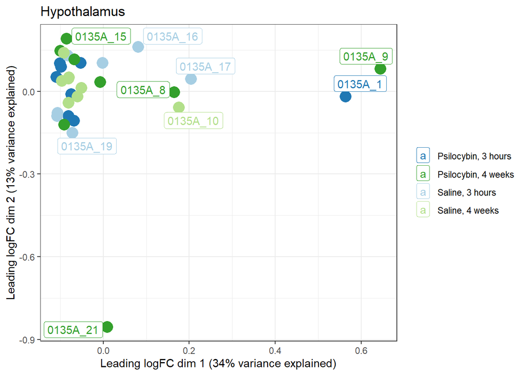

```r
ggplot_mds(y[, y$samples$tissue == "Hypothalamus"], dim_plot = c(1, 2),
           colour_by = "group"
           ) +
  colour_scale +
  ggtitle("Hypothalamus")
```

We see that the major variation in Hypothalamus is due to small number of samples, the differential expression analysis is robust to outliers and we will investigate these samples individually later. For now we exclude the three most outlying samples for the purpose of plotting.

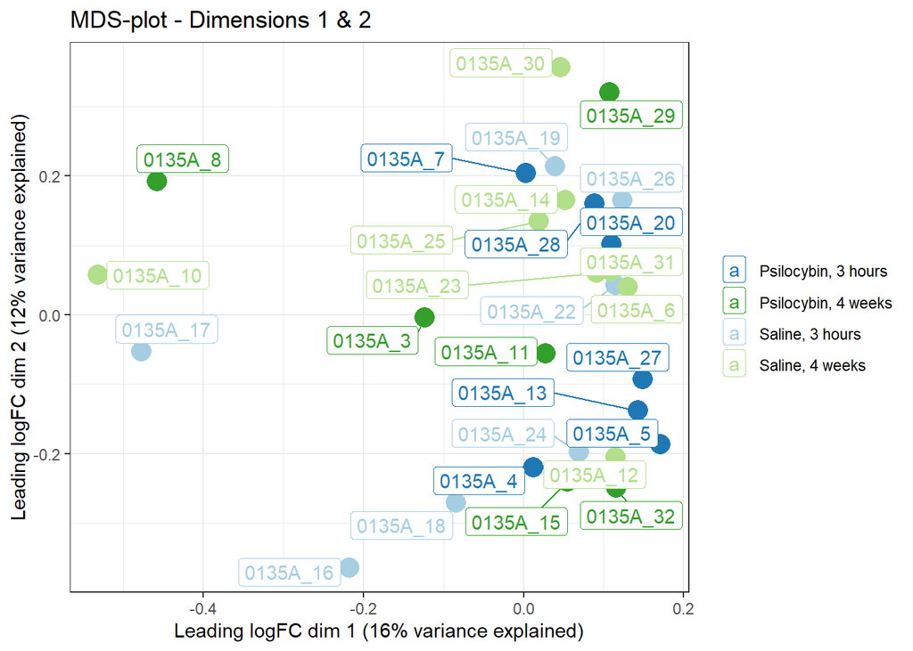

```r
excluded_samples <- c("0135A_21", "0135A_1", "0135A_9")
idx_hyp <- y$samples$tissue == "Hypothalamus"
idx_included <- !(y$samples$Sample.ID..Library.ID. %in% excluded_samples)
ggplot_mds(y[, idx_hyp & idx_included], dim_plot = c(1, 2),
           colour_by = "group") +
           colour_scale
```

We still see a number of samples separate from the main bulk on the first dimension. The sample to sample variation seems to be the largest source of variation in the dataset. On the second dimension we see a slight separation into two groups, but not caused by the experimental treatments.

The samples were extracted in two batches. We colour by batch.

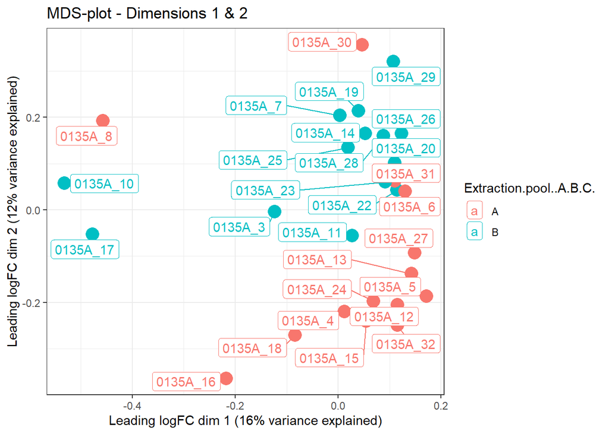

```r
ggplot_mds(y[, idx_hyp & idx_included], dim_plot = c(1, 2),
           colour_by = "Extraction.pool..A.B.C.")
```

There is a clear separation by extraction pool. We correct for this and plot again.

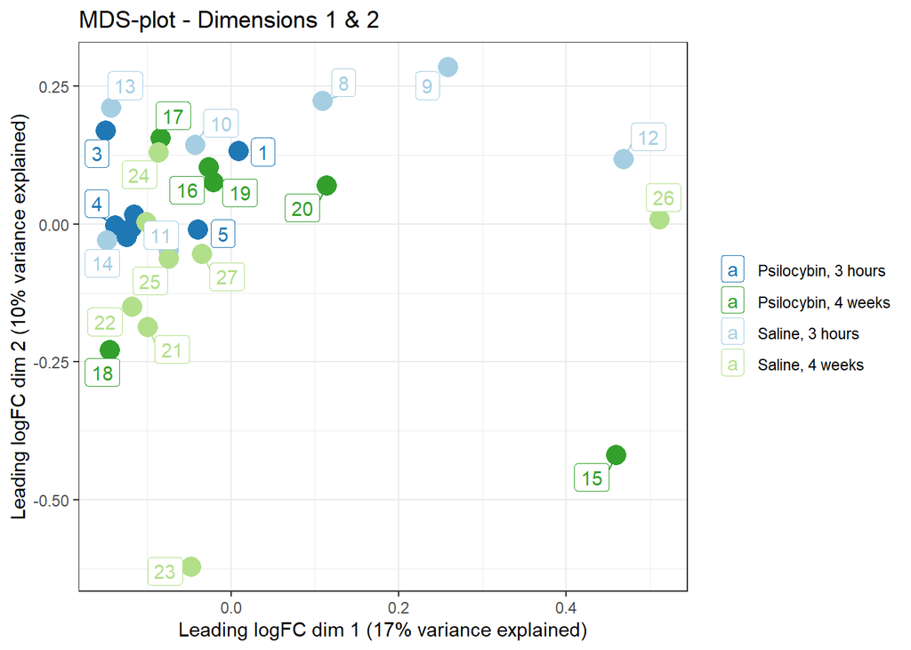

```r
y_hyp <- y[, idx_hyp & idx_included]
design_hyp <- model.matrix(~ 0 + group, data = y_hyp$samples)

cpm_hyp <- cpm(y_hyp, log = TRUE)
cpm_hyp <- removeBatchEffect(cpm_hyp,
                             batch = y_hyp$samples$Extraction.pool..A.B.C.,
                             design = design_hyp)

ggplot_mds(cpm_hyp,
           dim_plot = c(1, 2),
           colour_by = y_hyp$samples$group
           ) +
  colour_scale
```

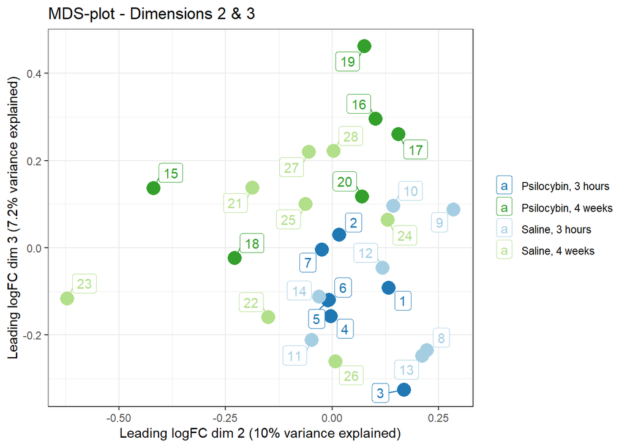

```r
ggplot_mds(cpm_hyp,
           dim_plot = c(2, 3),
           colour_by = y_hyp$samples$group
           ) +
  colour_scale
```

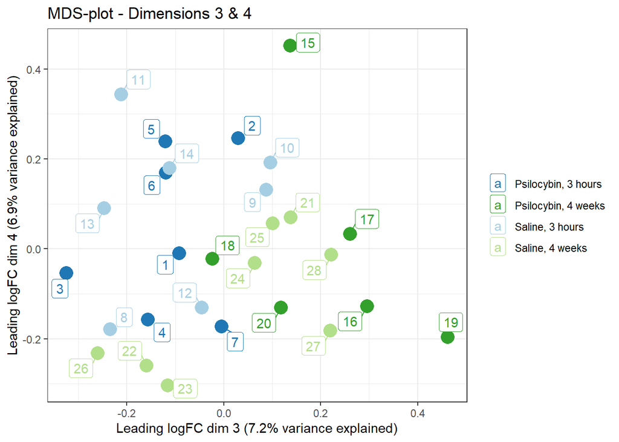

```r
ggplot_mds(cpm_hyp,
           dim_plot = c(3, 4),
           colour_by = y_hyp$samples$group
           ) +
  colour_scale
```

The largest source of variation is still individual samples, but in the higher dimensions some separation between the 3 hours and 4 weeks time point is observed.

The outlying samples are sample 0135A_21, which is located on it own, 0135A_9 and 0135A_1 which cluster together, but far from all other samples and finally 0135A_17, 0135A_8, 0135A_10 which cluster together in the same direction on dimension 1 as 0135A_9 and 0135A_1. We investigate which genes are different in these samples compared to the rest.

```r
hypothalamus <- y[, y$samples$tissue == "Hypothalamus"]

sample21 <- cpmByGroup(hypothalamus, group = hypothalamus$samples$Sample.ID..Library.ID. == "0135A_21", log = TRUE)
sample_order <- order(abs(sample21[, "TRUE"] - sample21[, "FALSE"]), decreasing = TRUE)
#write_clip(rownames(sample21)[sample_order])


samples9_and_1 <- cpmByGroup(hypothalamus, group = hypothalamus$samples$Sample.ID..Library.ID. %in%
                               c("0135A_9", "0135A_1"), log = TRUE)
sample_order <- order(abs(samples9_and_1[, "TRUE"] - samples9_and_1[, "FALSE"]), decreasing = TRUE)
#write_clip(rownames(samples9_and_1)[sample_order])


samples9_1_17_8_10 <- cpmByGroup(hypothalamus, group = hypothalamus$samples$Sample.ID..Library.ID. %in%
                                   c("0135A_9", "0135A_1", "0135A_17", "0135A_8", "0135A_10"), log = TRUE)
sample_order <- order(abs(samples9_1_17_8_10[, "TRUE"] - samples9_1_17_8_10[, "FALSE"]), decreasing = TRUE)
#write_clip(rownames(samples9_1_17_8_10)[sample_order])

out <- data.table(
  Sample21 = sample21[, "FALSE"] - sample21[, "TRUE"],
  Samples9_and_1 = samples9_and_1[, "FALSE"] - samples9_and_1[, "TRUE"],
  Samples9_1_17_8_10 = samples9_1_17_8_10[, "FALSE"] - samples9_1_17_8_10[, "TRUE"],
  ENSEMBL = rownames(hypothalamus)
)

conv <- bitr(out$ENSEMBL, "ENSEMBL", c("SYMBOL", "GENENAME"), org.Mm.eg.db)
setDT(conv, key = "ENSEMBL")
conv <- conv[out$ENSEMBL, , mult = "first"]
out <- merge(out, conv, by = "ENSEMBL")

writexl::write_xlsx(out, path = here::here("doc/hypothalamus_outliers.xlsx"))
```

The outlying samples are enriched for a long list of terms, these terms vary between the three groups investigated but are heavily enriched for terms related to wound healing and immune system. Sample 21 has 35.72% of genes being up or down more than two fold, and is excluded since it seems to be an entirely different sample than the rest. The remaining samples have 3.05% and 1.82% samples up or down by more than two fold and are retained.

### Visalization and investigation of potential outliers in PFC

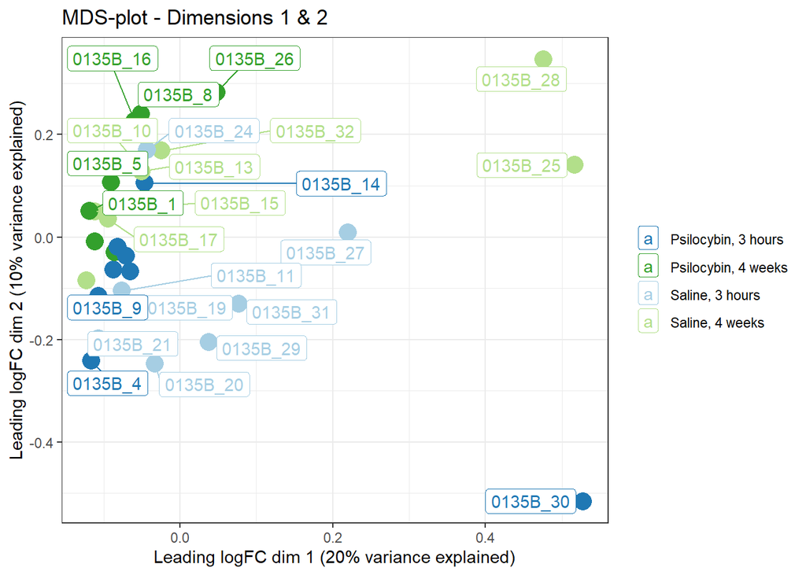

```r
ggplot_mds(y[, y$samples$tissue == "PFC"], dim_plot = c(1, 2),
           colour_by = "group"
           ) +
  colour_scale
```

We see that the major variation in PFC is again due to small number of samples, as before we will investigate these samples individually later. For now we exclude the three most outlying samples to look for other groupings.

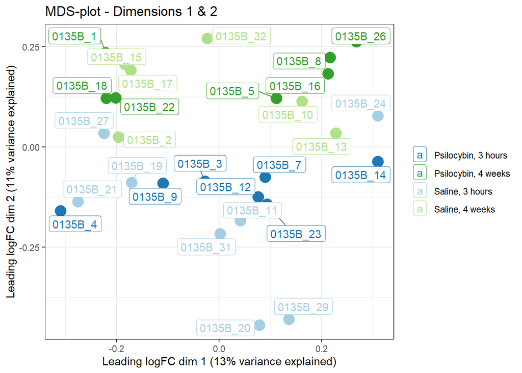

```r
excluded_samples <- c("0135B_28", "0135B_25", "0135B_30")
idx_pfc <- y$samples$tissue == "PFC"
idx_included <- !(y$samples$Sample.ID..Library.ID. %in% excluded_samples)

ggplot_mds(y[, idx_pfc & idx_included], dim_plot = c(1, 2),
           colour_by = "group") +
           colour_scale
```

The remaining samples look fairly homogeneous, with a clear separation between the 3 hours and 4 weeks time point. We try colouring by extraction pool, as we saw an effect in hypothalamus.

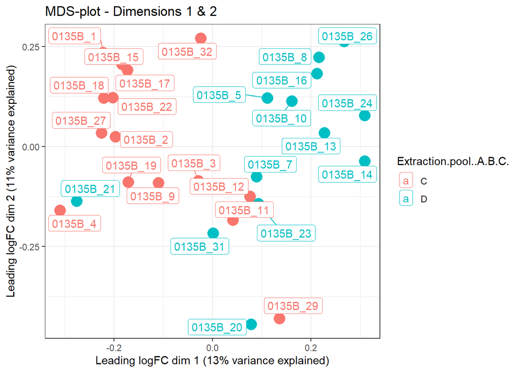

```r
ggplot_mds(y[, idx_pfc & idx_included], dim_plot = c(1, 2),
           colour_by = "Extraction.pool..A.B.C.")
```

Extraction pool separates the samples on the x-axis.

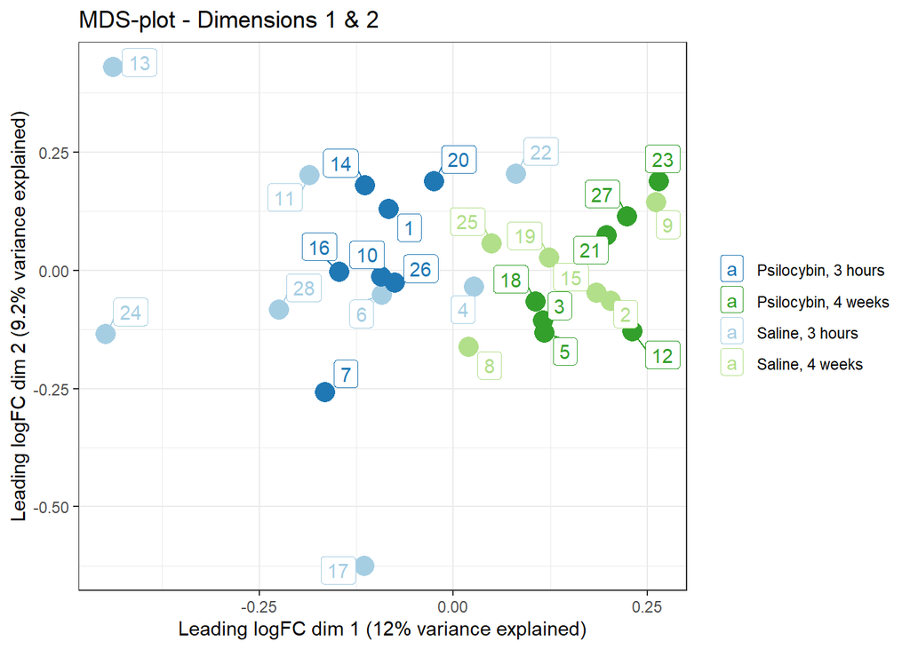

```r
y_pfc <- y[, idx_pfc & idx_included]
design_pfc <- model.matrix(~ 0 + group, data = y_pfc$samples)

cpm_pfc <- cpm(y_pfc, log = TRUE)
cpm_pfc <- removeBatchEffect(cpm_pfc,
                             batch = y_pfc$samples$Extraction.pool..A.B.C.,
                             design = design_pfc)

ggplot_mds(cpm_pfc, dim_plot = c(1, 2),
           colour_by = y_pfc$samples$group
           ) +
  colour_scale
```

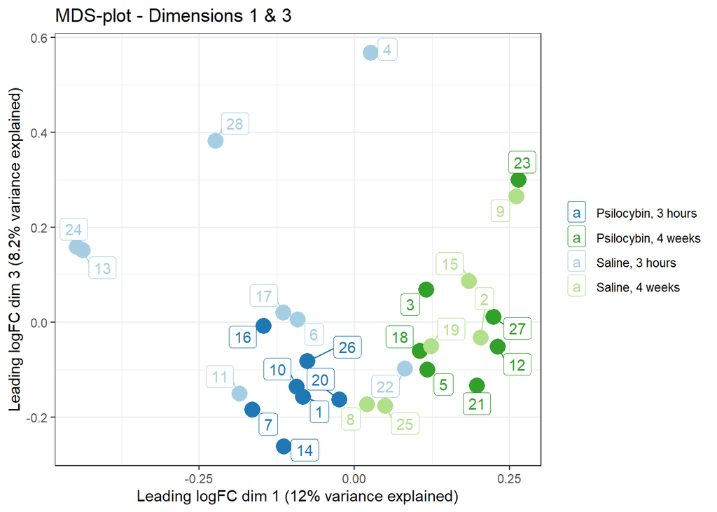

```r
ggplot_mds(cpm_pfc, dim_plot = c(1, 3),
           colour_by = y_pfc$samples$group
           ) +
           colour_scale
```

We still see a separation between the 3 hours and 4 weeks time point, but no big difference between saline and psilocybin.

The outlying samples are sample 0135B_28, 0135B_25, 0135B_30 but far from all other samples in the same direction on dimension 1. We investigate which genes are different in these samples compared to the rest.

```r
pfc <- y[, y$samples$tissue == "PFC"]

sample28_25_30 <- cpmByGroup(pfc, group = pfc$samples$Sample.ID..Library.ID. %in% c("0135B_28", "0135B_25", "0135B_30"), log = TRUE)
sample_order <- order(abs(sample28_25_30[, "TRUE"] - sample28_25_30[, "FALSE"]), decreasing = TRUE)
#write_clip(rownames(sample28_25_30)[sample_order])

out <- data.table(
  Sample28_25_30 = sample28_25_30[, "FALSE"] - sample28_25_30[, "TRUE"],
  ENSEMBL = rownames(hypothalamus)
)
out <- merge(out, conv, by = "ENSEMBL")

writexl::write_xlsx(out, path = here::here("doc/pfc_outliers.xlsx"))
```

The outlying samples are again enriched for a long list of terms heavily enriched for terms related to wound healing and immune system. We retain these samples as they only have 3.31% of genes with a fold change greater than two.

### Final RNA pre processing

Due to the large variation in sample quality, and the fact that all cages are not present in all samples, we will use voom to analyse this data.

The cage information did not add to the the model (not shown here) and were thus not included in the final model.

```r
y <- prepare_rna_dgelist(counts, metadata, sample_col = "Sample ID (Library ID)")
y$genes$Geneid <- str_remove(y$genes$Geneid, "\\.[[:digit:]]+$")
rownames(y) <- y$genes$Geneid
colnames(y$samples)[colnames(y$samples) == "Extraction.pool..A.B.C."] <- "Extraction_pool"
colnames(y$samples)[colnames(y$samples) == "Cage....1.2.3."] <- "Cage"
y$samples$Cage <- as.factor(y$samples$Cage)

y$samples$group <- factor(paste0(y$samples$tissue, "_",
                                 y$samples$Condition.1, "_",
                                 y$samples$Condition.2
))

y <- y[, !(y$samples$Sample.ID..Library.ID. %in% c("0135A_2", "0135A_21", "0135B_6"))]

conv <- bitr(rownames(y$genes), fromType = "ENSEMBL",
             toType = c("SYMBOL", "GENENAME"), OrgDb = org.Mm.eg.db)
```

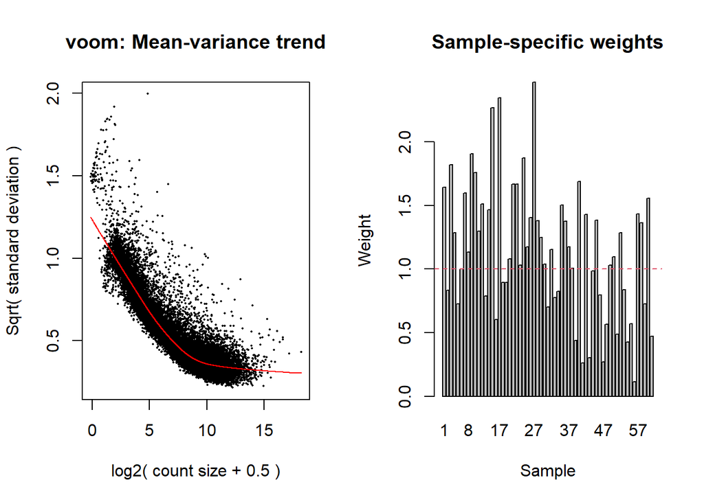

```r
setDT(conv, key = "ENSEMBL")
conv <- conv[y$genes$Geneid, , mult = "first"]

y$genes <- merge(y$genes, conv, by.x = "Geneid", by.y = "ENSEMBL")
stopifnot(all(y$genes$Geneid == rownames(y)))

Hypothalamus_ExtractionB <- y$samples$Extraction_pool == "B"
PFC_ExtractionB <- y$samples$Extraction_pool == "D"

design <- model.matrix(~ 0 + group, data = y$samples)
design <- cbind(design, Hypothalamus_ExtractionB, PFC_ExtractionB)


idx_expressed <- filterByExpr(y, design = design)
y <- y[idx_expressed, ]

y <- calcNormFactors(y)
y <- estimateDisp(y, design = design)

v <- voomWithQualityWeights(y, design = design, plot = FALSE)
corfit <- duplicateCorrelation(v, design, block = v$targets$Animal.ID)
v <- voomWithQualityWeights(y, design, block = v$targets$Animal.ID,
                            correlation = corfit$consensus, plot = TRUE)
```

```r
fit <- lmFit(v, design = v$design)
```

We check the weight of the samples identified as potentially problematic.

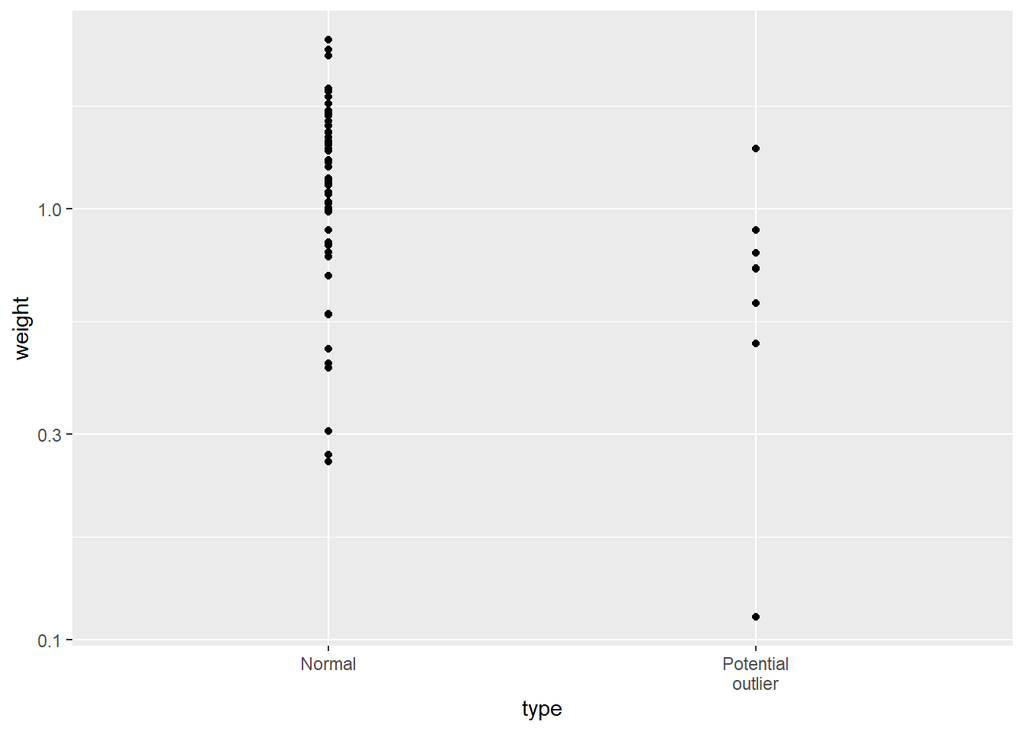

```r
problem_samples <- c("0135A_9", "0135A_1", "0135A_17", "0135A_8", "0135A_10", "0135B_28", "0135B_25", "0135B_30")
pD <- data.frame(weight = v$targets$sample.weights,
           type = fifelse(v$targets$Sample.ID..Library.ID. %in% problem_samples, "Potential\noutlier", "Normal"),
           name = v$targets$Sample.ID..Library.ID.)

ggplot(pD, aes(x = type, y = weight)) +
  geom_point() +
  scale_y_log10()
```

The model generally downweighs the samples we identified but also seems to downweigh a number of samples we did not identify.

## Differential expression

Next we check that the batches we have added are significant, and that they all follow either a uniform distribution or have an increased number of low P-values.

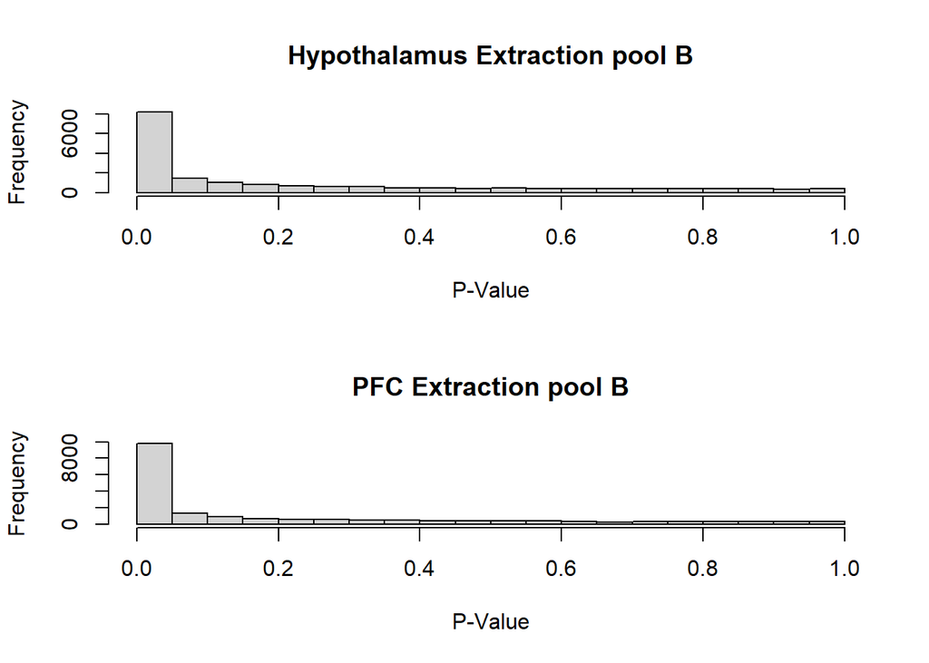

```r
fit_initial <- eBayes(fit)

withr::with_par(list(mfrow = c(2,1)),
                {
                  hist(fit_initial$p.value[, "Hypothalamus_ExtractionB"], main = "Hypothalamus Extraction pool B", xlab = "P-Value")
                  hist(fit_initial$p.value[, "PFC_ExtractionB"], main = "PFC Extraction pool B", xlab = "P-Value")
                })
```

The two extraction pools are highly highly enriched for genes with low P-values. Next we fit the contrasts of interests, and visualize the distribution of P-values.

```r
contrast_matrix <- makeContrasts(
  Hyp_Psilocybin_effect_at_3hours = (groupHypothalamus_Psilocybin_3hours - groupHypothalamus_Saline_3hours),
  Hyp_Psilocybin_effect_at_4weeks = (groupHypothalamus_Psilocybin_4weeks - groupHypothalamus_Saline_4weeks),
  Hyp_time_effect_in_saline = (groupHypothalamus_Saline_4weeks - groupHypothalamus_Saline_3hours),
  Hyp_time_effect_in_psilocybin = (groupHypothalamus_Psilocybin_4weeks - groupHypothalamus_Psilocybin_3hours),
  Hyp_Interaction = (groupHypothalamus_Psilocybin_4weeks - groupHypothalamus_Saline_4weeks) -
    (groupHypothalamus_Psilocybin_3hours - groupHypothalamus_Saline_3hours),
  PFC_Psilocybin_effect_at_3hours = (groupPFC_Psilocybin_3hours - groupPFC_Saline_3hours),
  PFC_Psilocybin_effect_at_4weeks = (groupPFC_Psilocybin_4weeks - groupPFC_Saline_4weeks),
  PFC_time_effect_in_saline = (groupPFC_Saline_4weeks - groupPFC_Saline_3hours),
  PFC_time_effect_in_psilocybin = (groupPFC_Psilocybin_4weeks - groupPFC_Psilocybin_3hours),
  PFC_Interaction = (groupPFC_Psilocybin_4weeks - groupPFC_Saline_4weeks) -
    (groupPFC_Psilocybin_3hours - groupPFC_Saline_3hours),
  levels = v$design
)

fit2 <- contrasts.fit(fit, contrast_matrix)
fit2 <- eBayes(fit2)
```

## Histogram of P-values

### Psilocybin and time in hypothalamus

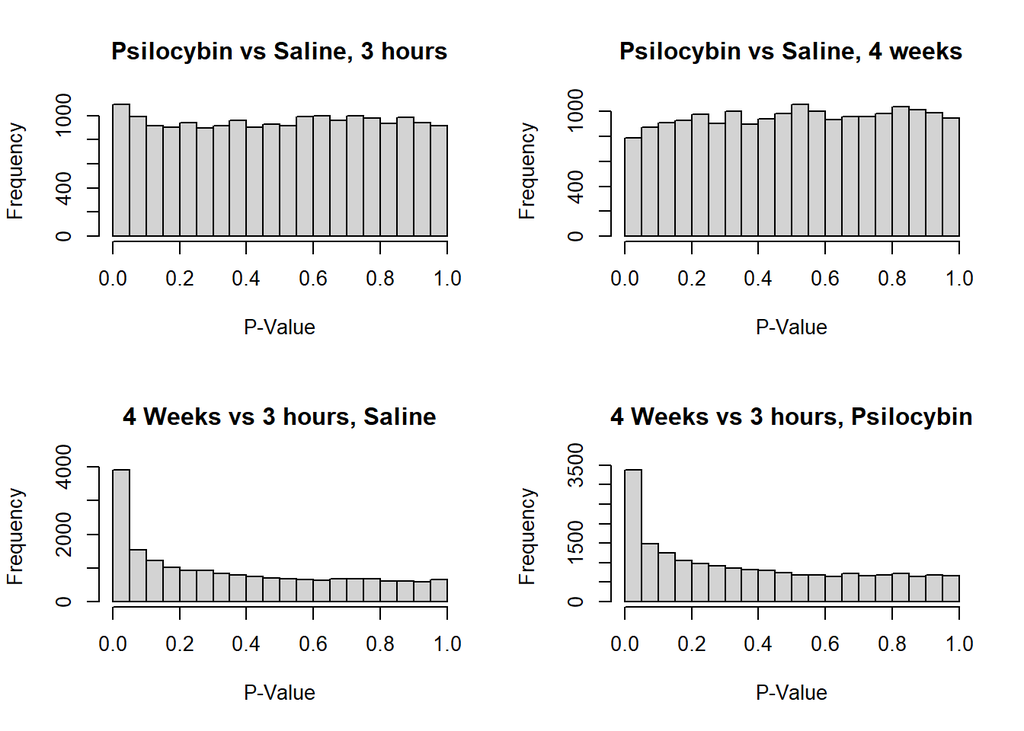

```r
withr::with_par(list(mfrow = c(2,2)),
                {
                  hist(fit2$p.value[, "Hyp_Psilocybin_effect_at_3hours"],
                       main = "Psilocybin vs Saline, 3 hours", xlab = "P-Value")
                  hist(fit2$p.value[, "Hyp_Psilocybin_effect_at_4weeks"],
                       main = "Psilocybin vs Saline, 4 weeks", xlab = "P-Value")
                  hist(fit2$p.value[, "Hyp_time_effect_in_saline"],
                       main = "4 Weeks vs 3 hours, Saline", xlab = "P-Value")
                  hist(fit2$p.value[, "Hyp_time_effect_in_psilocybin"],
                       main = "4 Weeks vs 3 hours, Psilocybin", xlab = "P-Value")
                })
```

In hypothalamus a clear effect of time is observed, while the effect of Psilocybin shows little evidence of significant effects at any timepoint.

### Psilocybin and time in PFC

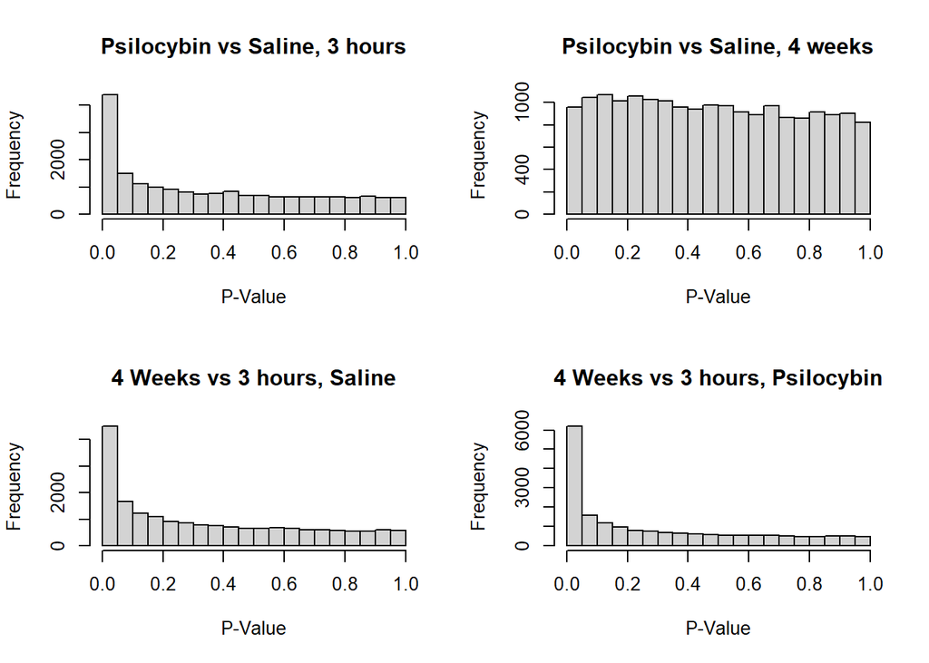

```r
withr::with_par(list(mfrow = c(2,2)),
                {
                  hist(fit2$p.value[, "PFC_Psilocybin_effect_at_3hours"],
                       main = "Psilocybin vs Saline, 3 hours", xlab = "P-Value")
                  hist(fit2$p.value[, "PFC_Psilocybin_effect_at_4weeks"],
                       main = "Psilocybin vs Saline, 4 weeks", xlab = "P-Value")
                  hist(fit2$p.value[, "PFC_time_effect_in_saline"],
                       main = "4 Weeks vs 3 hours, Saline", xlab = "P-Value")
                  hist(fit2$p.value[, "PFC_time_effect_in_psilocybin"],
                       main = "4 Weeks vs 3 hours, Psilocybin", xlab = "P-Value")
                })
```

In PFC a clear effect of time is observed, and a strong enrichment of low P-values in Psilocybin treatment at 3 hours, but little evidence of significant effects at 4 weeks.

### Interaction

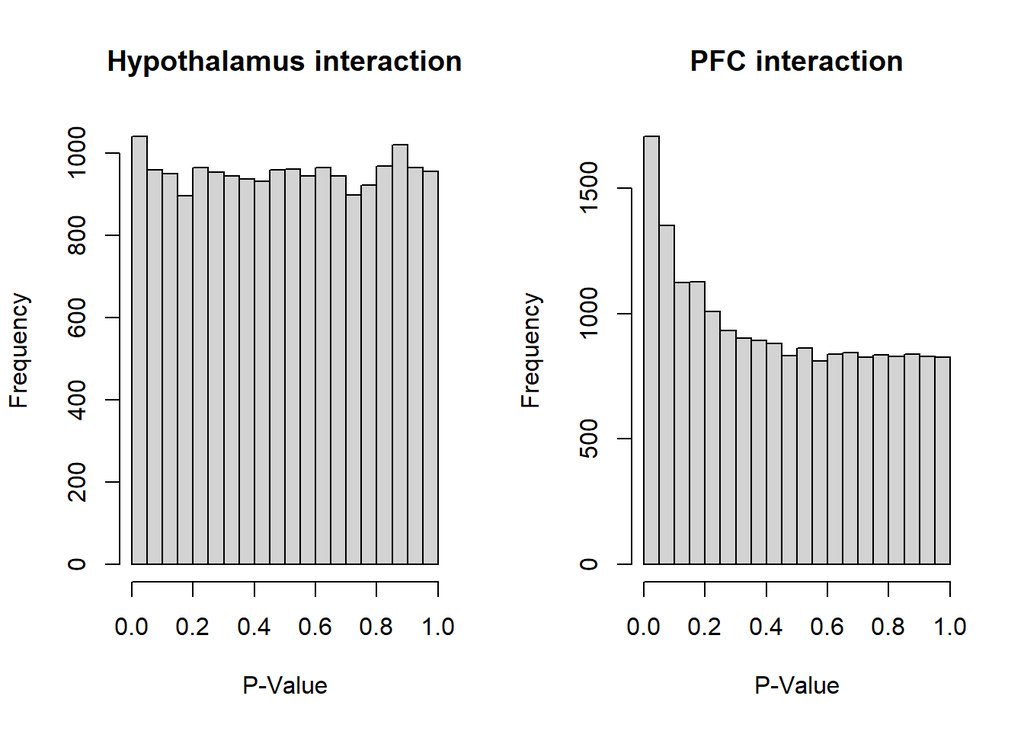

```r
withr::with_par(list(mfrow = c(1,2)),
                {
                  hist(fit2$p.value[, "Hyp_Interaction"],
                       main = "Hypothalamus interaction", xlab = "P-Value")
                  hist(fit2$p.value[, "PFC_Interaction"],
                       main = "PFC interaction", xlab = "P-Value")
                })
```

As expected an enrichment of low P-values is observed in the PFC interaction is observed.

We save the differential expression results in an excel file.

```r
contrasts <- colnames(contrast_matrix)
names(contrasts) <- contrasts
dge_res <- lapply(contrasts, topTable, fit = fit2, number = Inf, p.value = 1)
names(dge_res) <- str_remove(names(dge_res), "othalamus")

writexl::write_xlsx(dge_res, path = here::here("doc/0135_Nicole_dge_results.xlsx"))
```

## Gene ontology analysis

```r
#terms <- get_enrichment_terms(org.Mm.eg.db, v$genes$Geneid, min_genes = 5, max_genes = 500)

#ontologies <- lapply(terms, run_ontology_tests,
#                     y = v,
#                     contrast_matrix = contrast_matrix,
#                     fun = limma::camera)

#writexl::write_xlsx(ontologies$BP, path = here::here("doc/0135_Nicole_ontologies_BP.xlsx"))
#writexl::write_xlsx(ontologies$MF, path = here::here("doc/0135_Nicole_ontologies_MF.xlsx"))
#writexl::write_xlsx(ontologies$CC, path = here::here("doc/0135_Nicole_ontologies_CC.xlsx"))
#writexl::write_xlsx(ontologies$Reactome, path = here::here("doc/0135_Nicole_ontologies_Reactome.xlsx"))
```

## Volcanoplots

Next we generate volcano plots. We make sure the logFC limits are the same across all plots.

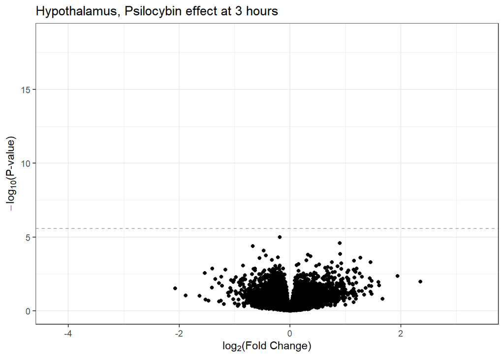

```r
source("~/scripts/plotting/findPvalueCutoff.R")

allLogFc <- unlist(lapply(dge_res, \(x) x[["logFC"]]))
minLogFc <- min(allLogFc)
maxLogFc <- max(allLogFc)
minPval <- -log10(lapply(dge_res, \(x) x[["P.Value"]]) |> unlist() |> min())
maxPval <- 0

plot_fn <- function(pD){
  ggplot(pD, aes(x = logFC,
                 y = -log10(P.Value),
                 #colour = abs(logFC) > 1 & adj.P.Val < 0.05
                 colour = adj.P.Val < 0.05
                 )
         ) +
    geom_point() +
#    geom_vline(xintercept = 1, linetype = 2, colour = 'darkgrey') +
#    geom_vline(xintercept = -1, linetype = 2, colour = 'darkgrey') +
    geom_hline(yintercept = -log10(findPvalueCutoff(pD$P.Value)), linetype = 2, colour = 'darkgrey') +
    scale_color_manual(values = c("TRUE" = "red", "FALSE" = "black"), name = element_blank(), labels = c("TRUE" = "Significant", "FALSE" = "Non-significant"), breaks = c("TRUE", "FALSE")) +
    ylab(expression(paste(-log[10], "(P-value)"))) +
    xlab(expression(paste(log[2], "(Fold Change)"))) +
    scale_x_continuous(limits = c(minLogFc, maxLogFc)) +
    scale_y_continuous(limits = c(maxPval, minPval)) +
    guides(colour = "none") +
    theme_bw()
}

plot_fn(dge_res$Hyp_Psilocybin_effect_at_3hours) + ggtitle("Hypothalamus, Psilocybin effect at 3 hours")
```

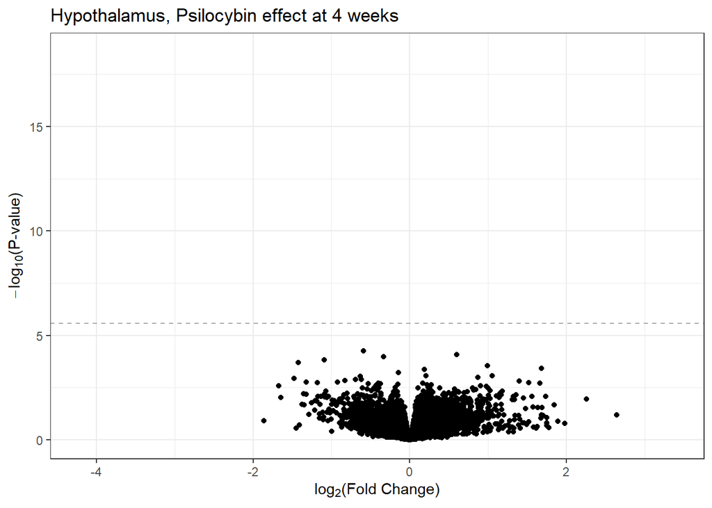

```r
plot_fn(dge_res$Hyp_Psilocybin_effect_at_4weeks) + ggtitle("Hypothalamus, Psilocybin effect at 4 weeks")
```

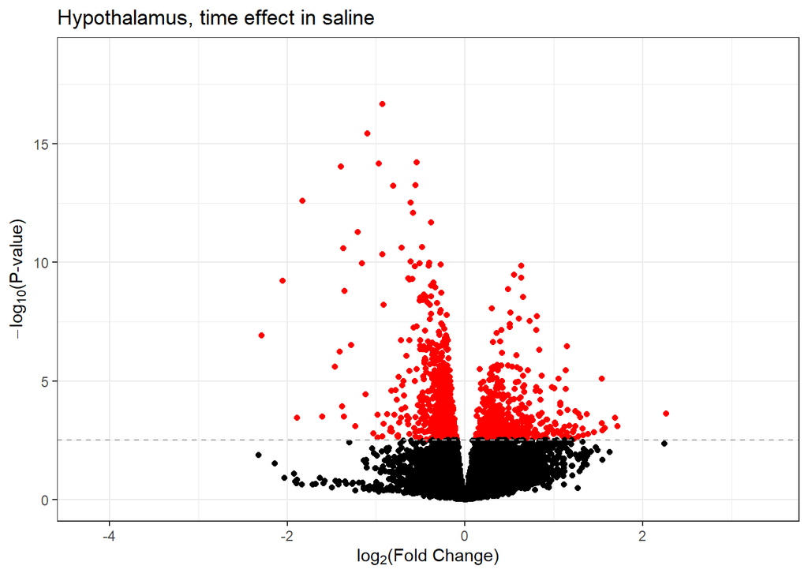

```r
plot_fn(dge_res$Hyp_time_effect_in_saline) + ggtitle("Hypothalamus, time effect in saline")
```

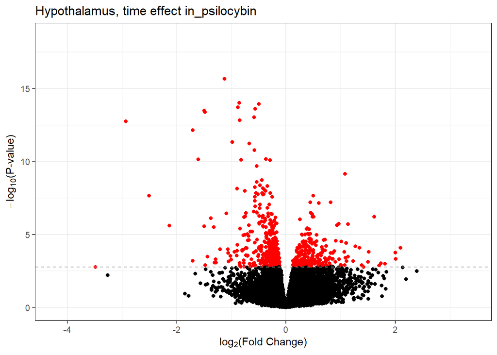

```r
plot_fn(dge_res$Hyp_time_effect_in_psilocybin) + ggtitle("Hypothalamus, time effect in_psilocybin")
```

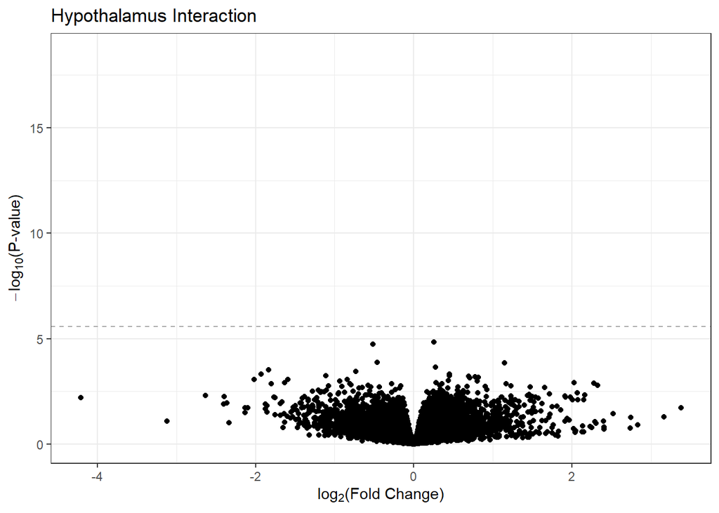

```r
plot_fn(dge_res$Hyp_Interaction) + ggtitle("Hypothalamus Interaction")
```

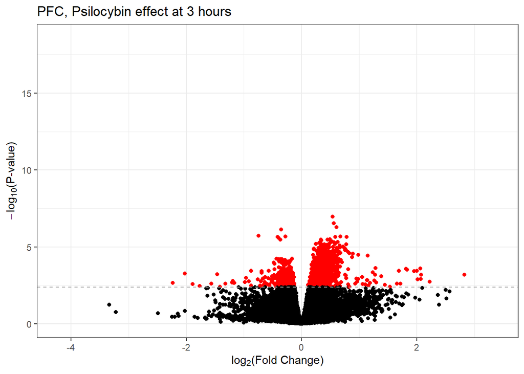

```r
plot_fn(dge_res$PFC_Psilocybin_effect_at_3hours) + ggtitle("PFC, Psilocybin effect at 3 hours")
```

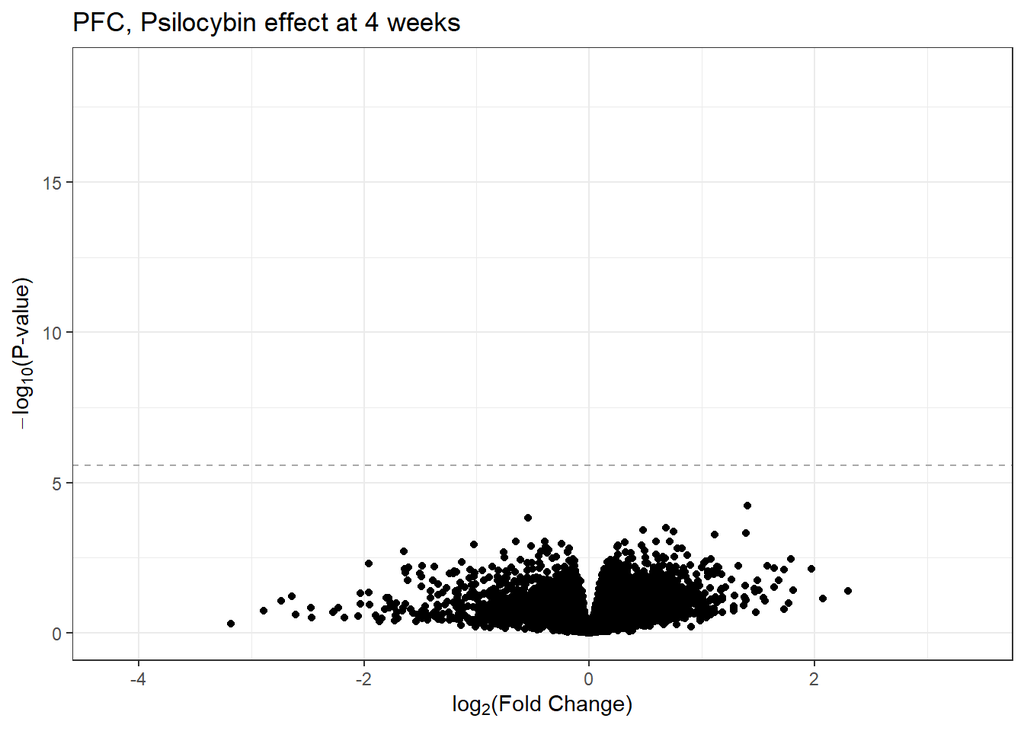

```r
plot_fn(dge_res$PFC_Psilocybin_effect_at_4weeks) + ggtitle("PFC, Psilocybin effect at 4 weeks")
```

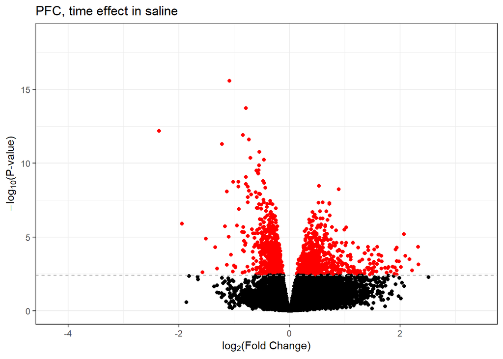

```r
plot_fn(dge_res$PFC_time_effect_in_saline) + ggtitle("PFC, time effect in saline")
```

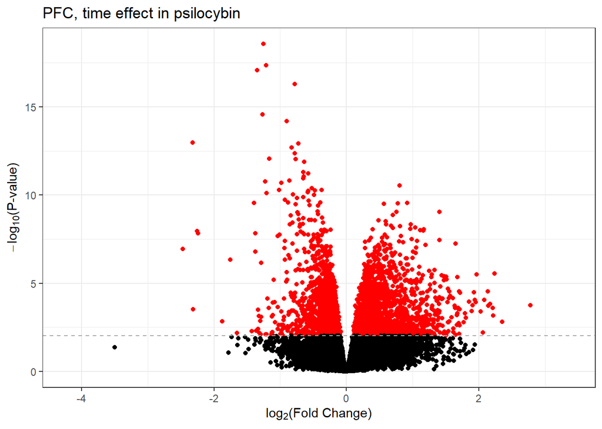

```r
plot_fn(dge_res$PFC_time_effect_in_psilocybin) + ggtitle("PFC, time effect in psilocybin")
```

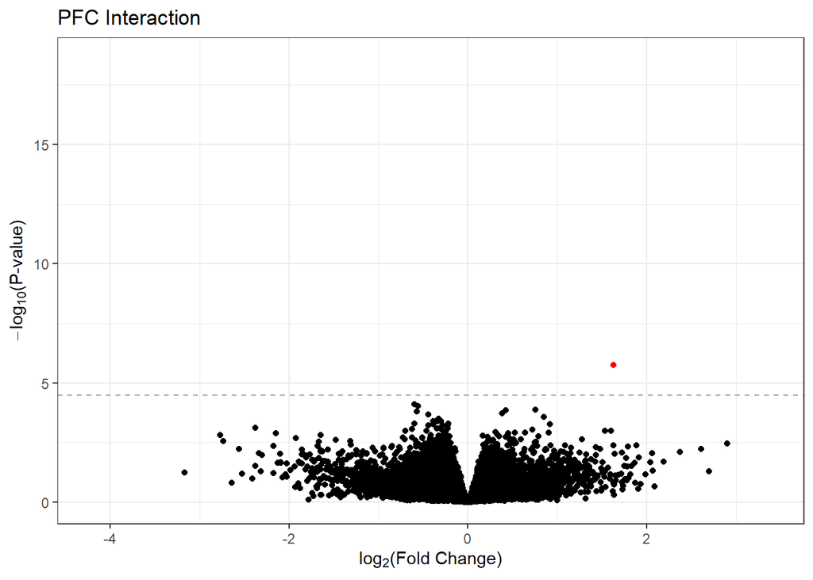

```r
plot_fn(dge_res$PFC_Interaction) + ggtitle("PFC Interaction")
```

## Heatmaps

Next we generate heatmaps of the tissue specific gene expressions. Samples and genes are clustered based on their correlation. The genes are normalized to have mean 0 and SD 1 prior to plotting, to make comparisons between genes with different expression levels possible. The colour scale is capped, so all genes with a score of less than -2 or greater than +2 are given the colour of -2 and +2 respectively.

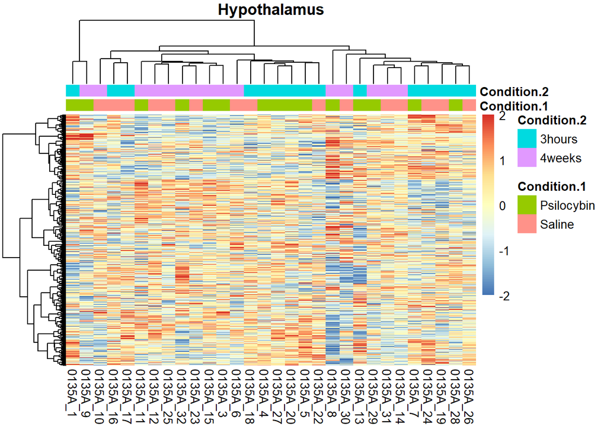

```r
heatmap_fn <- function(pD, main) {
  cor_dist_row <- as.dist(sqrt(1/2 * (1 - cor(t(pD)))))
  cor_dist_col <- as.dist(sqrt(1/2 * (1 - cor(pD))))

  annot_col <- y$samples[colnames(pD), c("Condition.1", "Condition.2"), drop = FALSE]

  colours <- colorRampPalette(rev(brewer.pal(n = 7, name = "RdYlBu")))(100)
  colours <- c(colours[[1]], colours, colours[[length(colours)]])
  breaks <- c(-Inf, seq(-2, 2, length.out = 101), Inf)

  pheatmap(pD, clustering_method = "ward.D2",
           clustering_distance_rows = cor_dist_row,
           clustering_distance_cols = cor_dist_col,
           scale = "row", show_rownames = FALSE,
           annotation_col = annot_col, color = colours, breaks = breaks,
           main = main)
}

pD <- cpm(y, log = TRUE)
pD <- removeBatchEffect(pD, covariates = y$design[, 9:10], design = y$design[, 1:8])

heatmap_fn(pD[, str_detect(colnames(pD), "A")], "Hypothalamus")
```

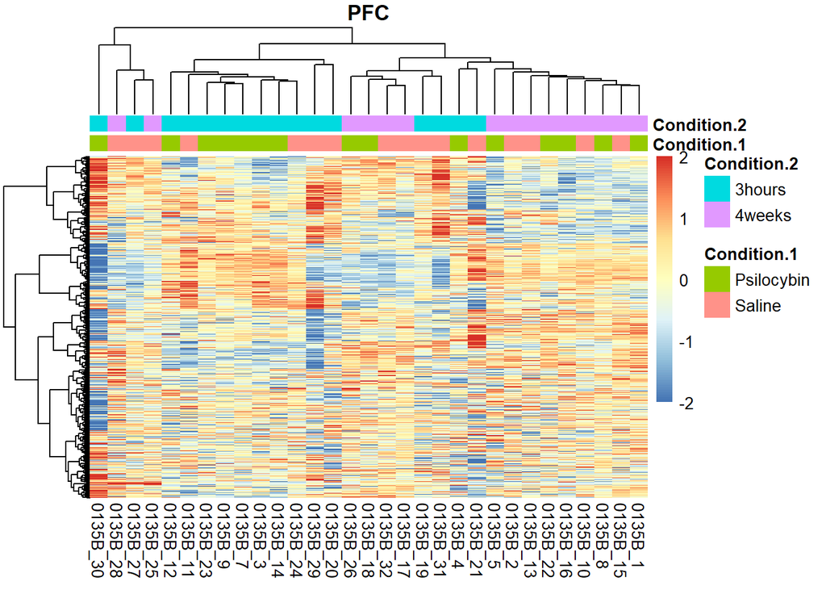

```r
heatmap_fn(pD[, str_detect(colnames(pD), "B")], "PFC")
```

We also plot only the genes significantly affected by Psilocybin at 3 hours in PFC and the top 100 genes for the treatment of Psilocybin at 3 hours in Hypothalamus.

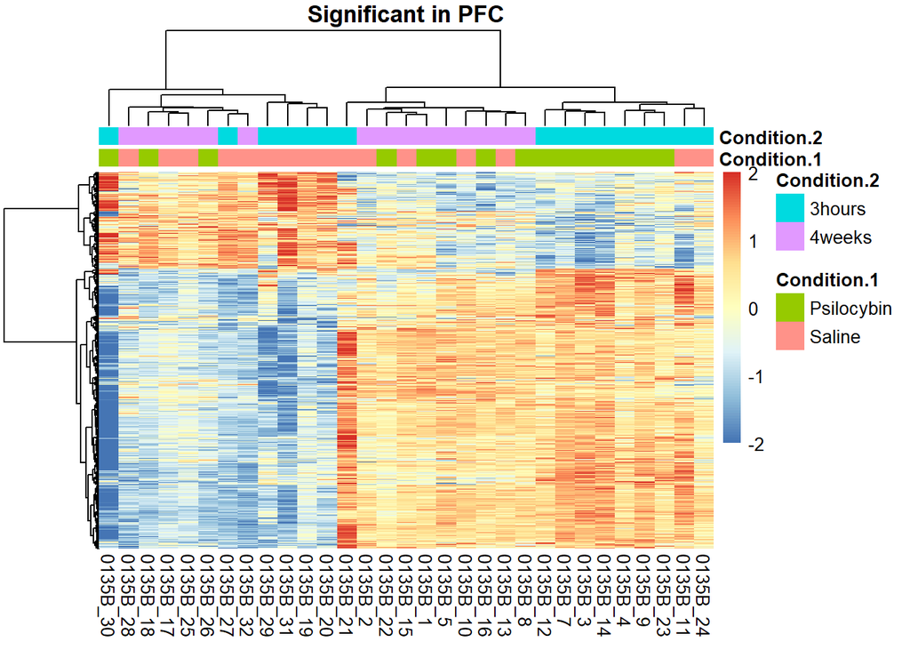

```r
idx_signif <- dge_res$PFC_Psilocybin_effect_at_3hours$adj.P.Val < 0.05
idx_signif <- dge_res$PFC_Psilocybin_effect_at_3hours$Geneid[idx_signif]
heatmap_fn(pD[idx_signif, str_detect(colnames(pD), "B")], main = "Significant in PFC")
```

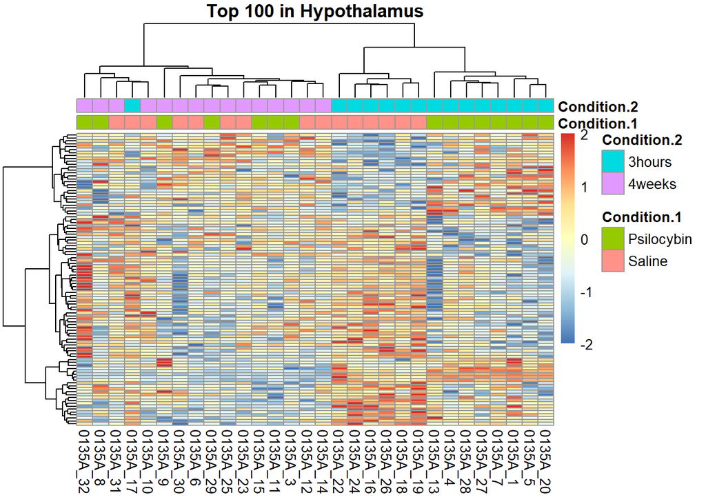

```r
idx_signif <- dge_res$Hyp_Psilocybin_effect_at_3hours$Geneid[1:100]
heatmap_fn(pD[idx_signif, str_detect(colnames(pD), "A")], main = "Top 100 in Hypothalamus")
```